# estimated marginal means

luke reding

3/10/2017

The goal here is to show how to use the `lsmeans` package in R to get the estimated marginal means from a model.

## What are estimated marginal means?

You have a model, but it’s complex. There might be a lot of covariates, or you might have a random effect or two. In these cases it’s difficult to simply show the data to show an effect. Instead, you can use estimated marginal means, or covariate-adjusted means. This allows you to show some effect you’re interested in independent of the effect that other varaibles in your model have.

## example using a linear model (lm())

Let’s use the `oranges` dataset that comes with `lsmeans` to flesh this out.

```r
library("lsmeans")
oranges.lm1 <- lm(sales1 ~ price1 + price2 + day + store, data = oranges)
car::Anova(oranges.lm1)
```

```
## Anova Table (Type II tests)
##
## Response: sales1
##           Sum Sq Df F value    Pr(>F)
## price1    538.17  1 30.3150 1.342e-05 ***
## price2     39.54  1  2.2274  0.149171
## day       433.10  5  4.8793  0.003456 **
## store     223.83  5  2.5217  0.058346 .
## Residuals 408.31 23
## ---
## Signif. codes:  0 '***' 0.001 '**' 0.01 '*' 0.05 '.' 0.1 ' ' 1
```

Part of what happens with the `lsmeans` package is that a *reference grid* is established. A reference grid is all the combinations of the factor levels of all the variables in the analysis; any numeric variables only get one level: their mean.

To see what this grid looks like for the `oranges` dataset:

```r
( oranges.rg1 <- ref.grid(oranges.lm1) )
```

```
## 'ref.grid' object with variables:
##     price1 = 51.222
##     price2 = 48.556
##     day = 1, 2, 3, 4, 5, 6
##     store = 1, 2, 3, 4, 5, 6
```

```r
summary(oranges.rg1)
```

```
##    price1   price2 day store prediction       SE df
##  51.22222 48.55556 1   1       2.918413 2.717559 23
##  51.22222 48.55556 2   1       3.848804 2.701335 23
##  51.22222 48.55556 3   1      11.018569 2.534556 23
##  51.22222 48.55556 4   1       6.096286 2.651370 23
##  51.22222 48.55556 5   1      12.795800 2.444597 23
##  51.22222 48.55556 6   1       8.748779 2.786176 23
##  51.22222 48.55556 1   2       4.961475 2.377742 23
##  51.22222 48.55556 2   2       5.891866 2.335579 23
##  51.22222 48.55556 3   2      13.061630 2.416451 23
##  51.22222 48.55556 4   2       8.139348 2.352186 23
##  51.22222 48.55556 5   2      14.838862 2.466155 23
##  51.22222 48.55556 6   2      10.791841 2.337599 23
##  51.22222 48.55556 1   3       3.200891 2.377742 23
##  51.22222 48.55556 2   3       4.131282 2.335579 23
##  51.22222 48.55556 3   3      11.301047 2.416451 23
##  51.22222 48.55556 4   3       6.378765 2.352186 23
##  51.22222 48.55556 5   3      13.078278 2.466155 23
##  51.22222 48.55556 6   3       9.031258 2.337599 23
##  51.22222 48.55556 1   4       6.198757 2.363673 23
##  51.22222 48.55556 2   4       7.129148 2.352186 23
##  51.22222 48.55556 3   4      14.298913 2.431679 23
##  51.22222 48.55556 4   4       9.376630 2.388653 23
##  51.22222 48.55556 5   4      16.076144 2.519089 23
##  51.22222 48.55556 6   4      12.029123 2.364688 23
##  51.22222 48.55556 1   5       5.543218 2.363116 23
##  51.22222 48.55556 2   5       6.473609 2.330670 23
##  51.22222 48.55556 3   5      13.643374 2.363673 23
##  51.22222 48.55556 4   5       8.721091 2.337599 23
##  51.22222 48.55556 5   5      15.420605 2.395544 23
##  51.22222 48.55556 6   5      11.373584 2.352318 23
##  51.22222 48.55556 1   6      10.563739 2.366683 23
##  51.22222 48.55556 2   6      11.494130 2.339254 23
##  51.22222 48.55556 3   6      18.663895 2.347839 23
##  51.22222 48.55556 4   6      13.741613 2.341304 23
##  51.22222 48.55556 5   6      20.441126 2.370343 23
##  51.22222 48.55556 6   6      16.394106 2.370539 23
```

The ANOVA showed a significant effect of *day*. Let’s compare plotting the actual data to extracting and plotting the estimated marginal means:

```r
library(tidyverse)
library(magrittr)
```

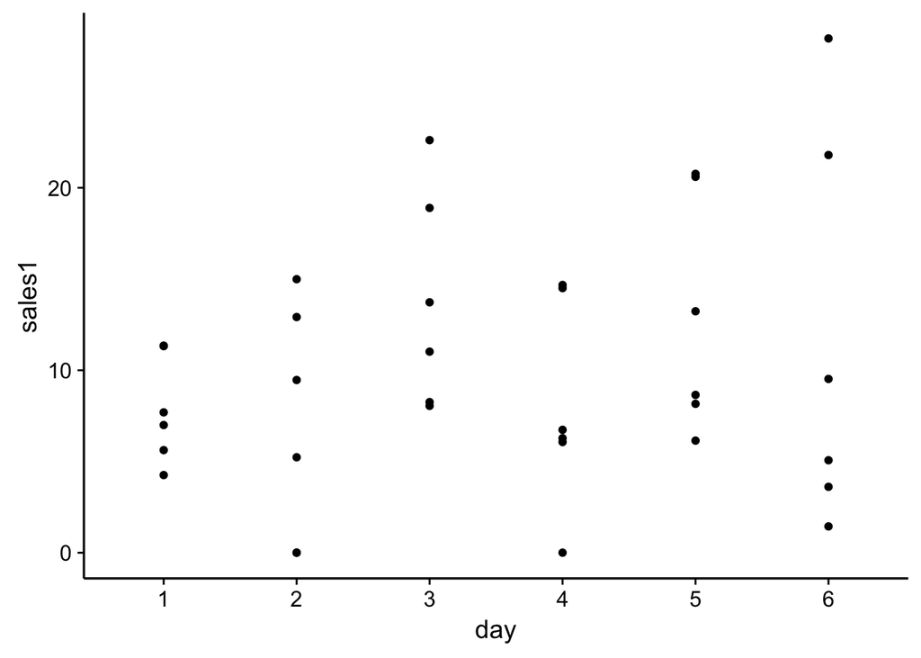

```r
source("~/Documents/random_scripts/plotting_functions.R")
ggplot(oranges, aes(y = sales1, x = day)) +
  geom_point() +
  theme_mod() +
  add_axes()
```

We can get the estimated marginal means by using:

```r
(marginal <- lsmeans(oranges.lm1, "day") %>% broom::tidy(.))
```

```
##   day  estimate std.error df  conf.low conf.high
## 1   1  5.564415  1.768083 23  1.906856  9.221974
## 2   2  6.494807  1.728959 23  2.918183 10.071430
## 3   3 13.664571  1.751505 23 10.041308 17.287835
## 4   4  8.742289  1.733920 23  5.155403 12.329175
## 5   5 15.441803  1.785809 23 11.747576 19.136029
## 6   6 11.394782  1.766726 23  7.740031 15.049533
```

This is the estimated `sales1` for each day averaged over all the variables in our model, `oranges.lm1`. I’ve also used the `broom` package here to make the output more useable and informatibe.

We could now plot these estimated means instead of the raw data:

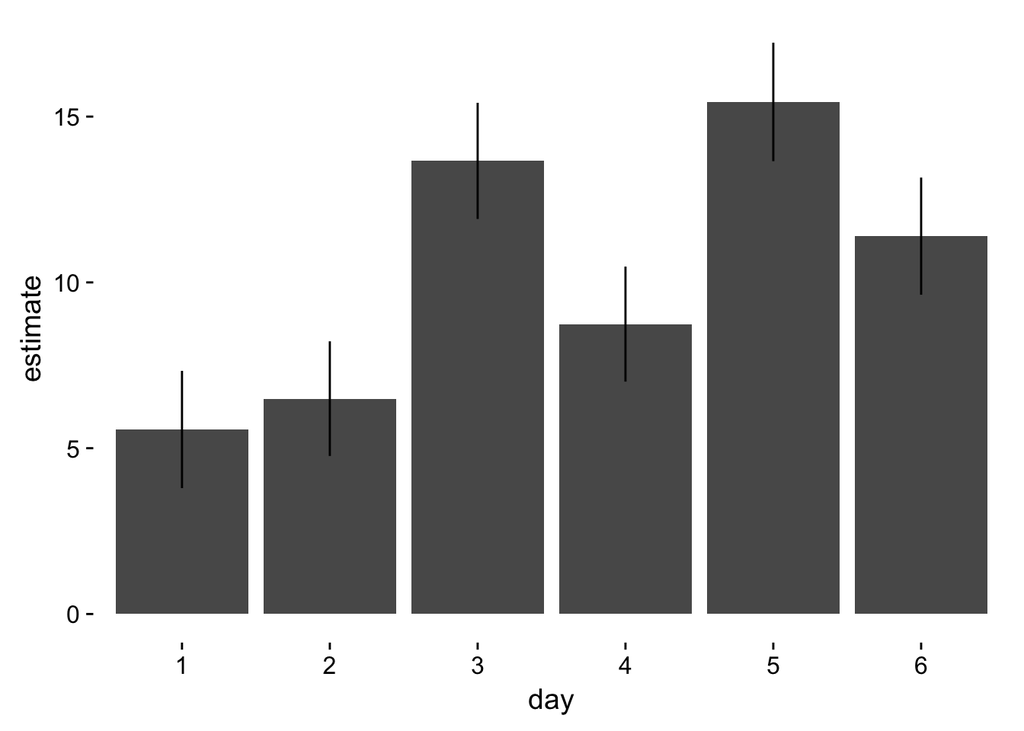

```r
marginal %>%
  ggplot(aes(x = day, y = estimate)) +
  geom_col() +
  geom_errorbar(aes(ymin=estimate-std.error, ymax=estimate+std.error), width = 0) +
  theme_mod()
```

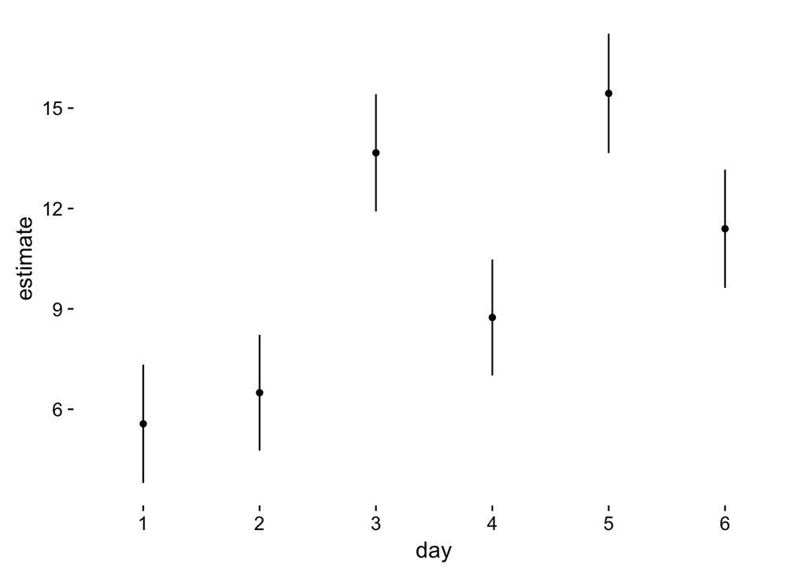

```r
## or
marginal %>%
  ggplot(aes(x = day, y = estimate)) +
  geom_point() +
  geom_errorbar(aes(ymin=estimate-std.error, ymax=estimate+std.error), width = 0) +
  theme_mod()
```

Here the effect is a bit more clearly seen and is more honest to the underlying statistical analysis used to analyze the data.

## more complicated

We can also do all sorts of stats on these marginal means. For example, in the previous example, we might want to test whether the price estimate on days 1 and 2 is different from the prices on the other days:

```r
days.lsm <- lsmeans(oranges.lm1, "day")
( days_contr.lsm <- contrast(days.lsm, "trt.vs.ctrl", ref = c(1,2)) )
```

```
##  contrast     estimate       SE df t.ratio p.value
##  3 - avg(1,2) 7.634960 2.143071 23   3.563  0.0060
##  4 - avg(1,2) 2.712678 2.144731 23   1.265  0.5285
##  5 - avg(1,2) 9.412192 2.217956 23   4.244  0.0012
##  6 - avg(1,2) 5.365171 2.155529 23   2.489  0.0685
##
## Results are averaged over the levels of: store
## P value adjustment: dunnettx method for 4 tests
```

As we can see from the plot above, day 4 and, to a lesster degree, day 6 aren’t too different from the prices on days 1 and 2, and the results of the code above verify this intuition.

You can also do something more general and compare all lsmeans to each other.

```r
pairs(lsmeans(oranges.lm1, "day"))
```

```
##  contrast   estimate       SE df t.ratio p.value
##  1 - 2    -0.9303912 2.466837 23  -0.377  0.9989
##  1 - 3    -8.1001559 2.465614 23  -3.285  0.0337
##  1 - 4    -3.1778735 2.505467 23  -1.268  0.7986
##  1 - 5    -9.8773872 2.559372 23  -3.859  0.0091
##  1 - 6    -5.8303666 2.519328 23  -2.314  0.2287
##  2 - 3    -7.1697647 2.479697 23  -2.891  0.0777
##  2 - 4    -2.2474823 2.442340 23  -0.920  0.9372
##  2 - 5    -8.9469960 2.516131 23  -3.556  0.0184
##  2 - 6    -4.8999755 2.447089 23  -2.002  0.3712
##  3 - 4     4.9222824 2.490068 23   1.977  0.3848
##  3 - 5    -1.7772313 2.471351 23  -0.719  0.9776
##  3 - 6     2.2697892 2.540282 23   0.894  0.9442
##  4 - 5    -6.6995137 2.488452 23  -2.692  0.1153
##  4 - 6    -2.6524931 2.446678 23  -1.084  0.8827
##  5 - 6     4.0470206 2.556559 23   1.583  0.6171
##
## Results are averaged over the levels of: store
## P value adjustment: tukey method for comparing a family of 6 estimates
```

Again, these p-values verify our intuition about the plot above.

It also might be useful to add letters or numbers to groups that don’t differ significantly:

```r
require(multcompView)
cld(days.lsm, alpha = .10)
```

```
##  day    lsmean       SE df  lower.CL  upper.CL .group
##  1    5.564415 1.768083 23  1.906856  9.221974  1
##  2    6.494807 1.728959 23  2.918183 10.071430  1
##  4    8.742289 1.733920 23  5.155403 12.329175  12
##  6   11.394782 1.766726 23  7.740031 15.049533  12
##  3   13.664571 1.751505 23 10.041308 17.287835   2
##  5   15.441803 1.785809 23 11.747576 19.136029   2
##
## Results are averaged over the levels of: store
## Confidence level used: 0.95
## P value adjustment: tukey method for comparing a family of 6 estimates
## significance level used: alpha = 0.1
```

## example using a linear mixed model (lmer())

```r
require("lme4")
data("Oats", package = "nlme")

Oats.lmer2 <- lmer(log(yield) ~ Variety + poly(nitro,2) + (1|Block/Variety),  data = Oats)
anova(Oats.lmer2)
```

```
## Analysis of Variance Table
##                Df Sum Sq Mean Sq F value
## Variety         2 0.0684  0.0342  2.0084
## poly(nitro, 2)  2 2.1350  1.0675 62.6929
```

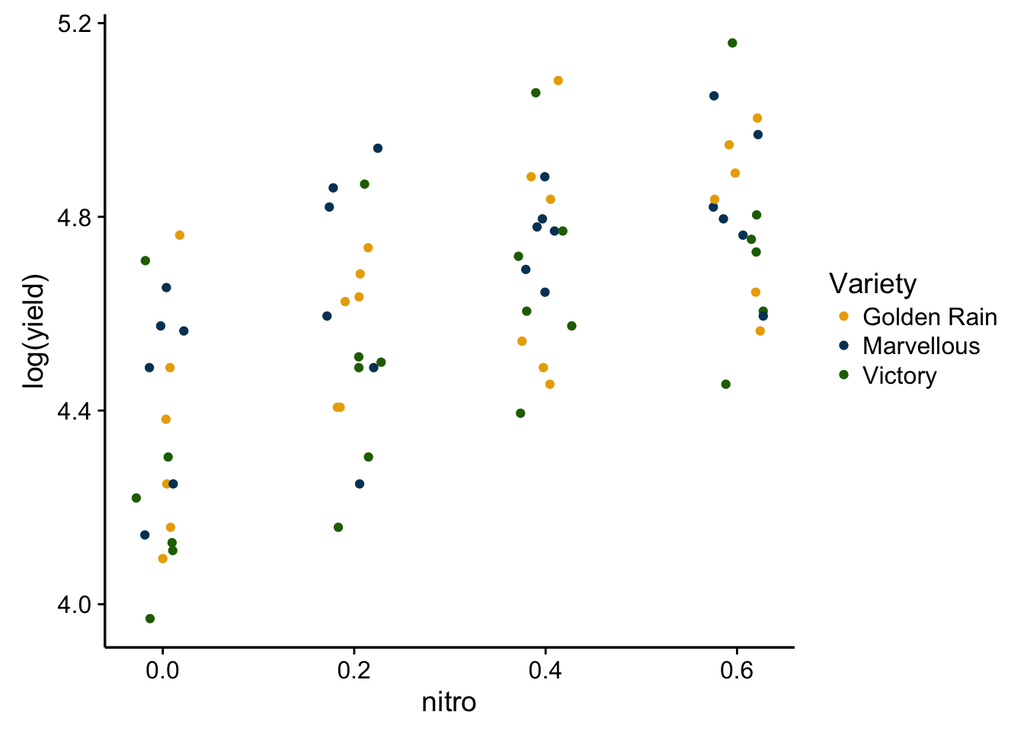

```r
ggplot(Oats, aes(x = nitro, y = log(yield), color = Variety)) +
  geom_jitter(height = 0, width = 0.03) +
  scale_color_classic() +
  theme_mod() +
  add_axes()
```

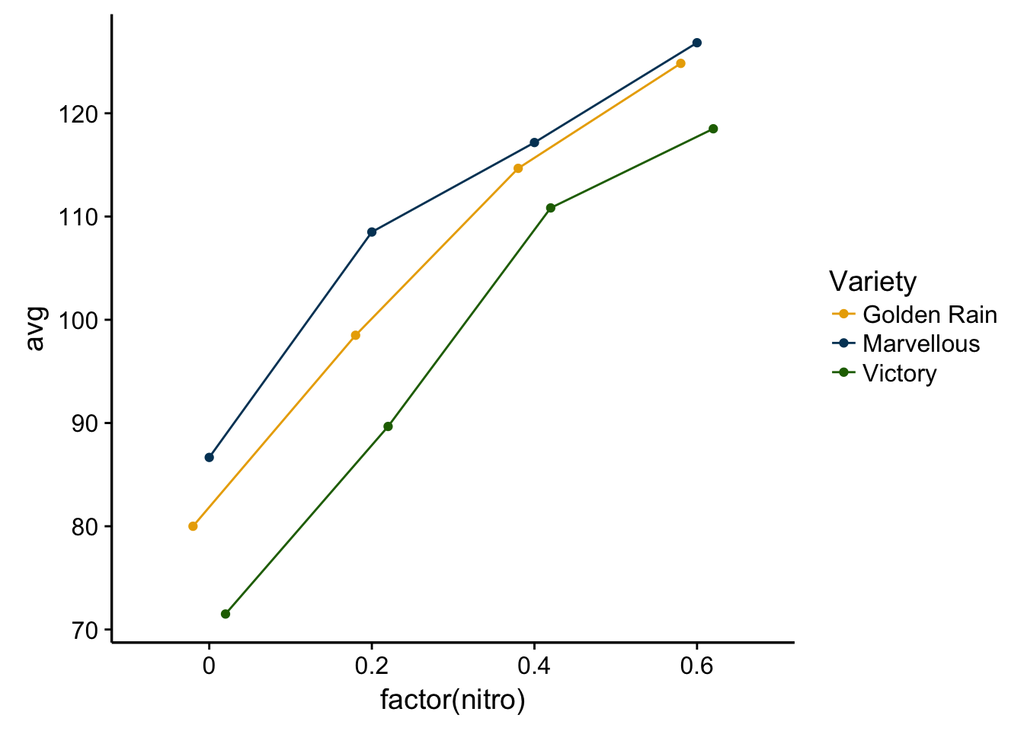

```r
## or

Oats %>%
  group_by(Variety, nitro) %>%
  summarise(avg = mean(yield, na.rm = T)) %>%
  ggplot(aes(factor(nitro), avg, color = Variety, group = Variety)) +
  geom_line(position = position_dodge(0.3)) +
  geom_point(position = position_dodge(0.3)) +
  scale_color_classic() +
  theme_mod() +
  add_axes()
```

Again, if we want to visualize the average effect of nitrogen on yeild, averaging across varieties and blocks, we can use:

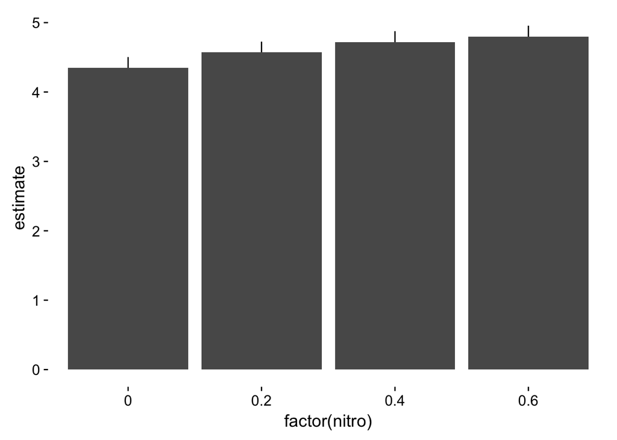

```r
(marginal <- lsmeans(Oats.lmer2, "nitro", cov.reduce = FALSE) %>% broom::tidy(.)) %>%
  ggplot(aes(x = factor(nitro), y = estimate)) +
  geom_errorbar(aes(ymin = conf.low, ymax = conf.high), width = 0) +
  geom_col() +
  theme_mod()
```

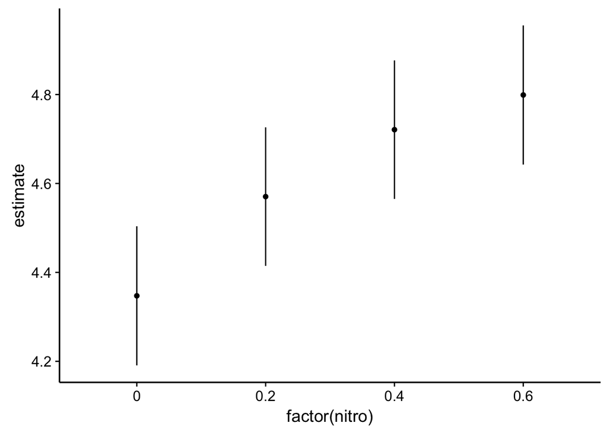

```r
## or
marginal %>%
  ggplot(aes(x = factor(nitro), y = estimate)) +
  geom_errorbar(aes(ymin = conf.low, ymax = conf.high), width = 0) +
  geom_point() +
  theme_mod() +
  add_axes()
```

Or, to show the average yeild by variety averaged across blocks:

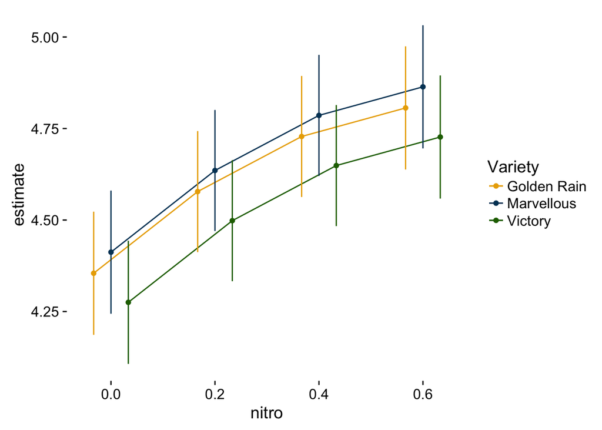

```r
## or
lsmeans(Oats.lmer2, "nitro", by = "Variety", cov.reduce = FALSE) %>%
  broom::tidy(.) %>%
  ggplot(aes(nitro, estimate, color = Variety)) +
  geom_line(position = position_dodge(0.1)) +
  geom_point(position = position_dodge(0.1)) +
  geom_errorbar(width = 0, aes(ymin = conf.low, ymax = conf.high), position = position_dodge(0.1)) +
  scale_color_classic() +
  theme_mod()
```

Nitro is a number, but it should really be treated as a factor. We can use `cov.reduce = FALSE` to tell lsmeans to treat numeric variables as factors:

```r
(Oats.lsm2 <- lsmeans(Oats.lmer2, ~ nitro | Variety, cov.reduce = FALSE))
```

```
## Variety = Golden Rain:
##  nitro   lsmean         SE    df lower.CL upper.CL
##    0.0 4.354578 0.07703285 11.77 4.186367 4.522789
##    0.2 4.577698 0.07453633 10.34 4.412352 4.743044
##    0.4 4.728263 0.07453633 10.34 4.562917 4.893609
##    0.6 4.806273 0.07703285 11.77 4.638062 4.974484
##
## Variety = Marvellous:
##  nitro   lsmean         SE    df lower.CL upper.CL
##    0.0 4.412227 0.07703285 11.77 4.244016 4.580438
##    0.2 4.635347 0.07453633 10.34 4.470001 4.800693
##    0.4 4.785912 0.07453633 10.34 4.620566 4.951258
##    0.6 4.863922 0.07703285 11.77 4.695711 5.032133
##
## Variety = Victory:
##  nitro   lsmean         SE    df lower.CL upper.CL
##    0.0 4.275147 0.07703285 11.77 4.106936 4.443358
##    0.2 4.498267 0.07453633 10.34 4.332921 4.663613
##    0.4 4.648832 0.07453633 10.34 4.483486 4.814178
##    0.6 4.726842 0.07703285 11.77 4.558631 4.895053
##
## Degrees-of-freedom method: satterthwaite
## Results are given on the log (not the response) scale.
## Confidence level used: 0.95
```

## more info

The vignette for lsmeans (`vignette("using-lsmeans")`) is super useful and a great resource.